# Summary

Customers are using TI’s mmWave radar sensors today to enable **high accuracy level measurements** of liquids and bulk materials in various industries including food and beverage, wastewater management and process industry. Our radar sensors offer **non-contact, maintenance free** measurement of fluid-levels up to 80m with extremely **high distance accuracy of <1mm** coupled with **low power consumption** targeting **4-20mA loop powered systems.**

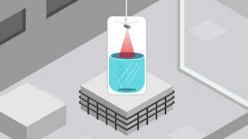

# TI’s Offering

What can TI’s IWR1443 mmWave radar sensor offer for Level Sensing?

1. **<1mm distance accuracy** enabling granular tank volume control
2. **Low energy consumption** of <18mJ/measurement
3. Measurement **minimally influenced by temperature and pressure variations** compared to ultrasonic sensors
4. Immune to foam, vapors, powder, dust and condensates
5. Can measure solid/powder levels

# Getting Started

Get started today with mmWave for Level Sensing!

## Featured Demonstration Videos:

[**Level Sensing using IWR mmWave sensors**](https://training.ti.com/node/1128704)

[figure not shown]

[**Fluid-level sensing demonstration using TI mmWave sensors**](https://training.ti.com/fluid-level-sensing-demonstration-using-ti-mmwave-sensors)

[video not shown]

## Development Resources

- TIDEP-0091 (Power optimization for 77GHz-level transmitter reference design)
- High Accuracy Range Measurement Lab with multipeak selection feature
- Measuring object height with mmWave radar – experiment

## Certification

- [TI mmWave Radar Device Regulatory Compliance Guide](http://www.ti.com/lit/spracp3)
- TI mmWave Certification Database

## Recommend Devices

- IWR1443 – 4Rx3Tx 77GHz mmWave radar sensor with integrated MCU & HWA (production)
  - Check out the IWR1443BOOST evaluation module to get started
- IWR6843 - 4Rx3Tx 60GHz mmWave radar sensor w/ DSP & HWA (production)
  - Check out the IWR6843ISK evaluation module to get started
- IWR6843AOP – IWR6843 with integrated antenna on the package (production)
  - Check out the IWR6843AOPEVM evaluation module to get started
- IWRL6432 - 3Rx2Tx low power, lower cost mmWave radar sensor with HWA (sampling now)
  - Check out the IWRL6432BOOST evaluation module to get started

## Functional Safety Resources

- [Understanding Functional Safety in Automotive and Industrial Applications](https://e2e.ti.com/blogs_/b/process/posts/understanding-the-importance-of-functional-safety-in-automotive-and-industrial-sensing-applications)
- [TI mmWave Functional Safety Enablers](http://www.ti.com/lit/sprt747)

# Third Party Resources

- [Designing TI mmWave radar made easier using our third-party ecosystem](https://e2e.ti.com/blogs_/b/industrial_strength/posts/ti-mmwave-radar-made-easy-with-our-third-party-ecosystem)
- [Browse third-party solutions and find the right third-party to meet your needs](https://www.ti.com/tool/MMWAVE-3P-SEARCH)

# Need more information?

- Visit the Industrial mmWave Radar Sensor portal at [ti.com/iwr](https://www.ti.com/sensors/mmwave-radar/industrial/overview.html)
- Search for your question or post a new question on the [mmWave E2E forum](https://e2e.ti.com/support/sensor/mmwave_sensors/f/1023)